# DRD_2026_Lesson_4.1

**CHUNK 1: PCA**. PCA can be used as a diagnostic plot for the detection of outliers and batch effects.  
We will use the function **prcomp()** to calculate the PCA on our matrix of normalized beta values.  
Let’s load our quantile-normalized DNA methylation data (Lesson 4) and the samplesheet with phenotypic information (Lesson 3):

```r
load("~/Dropbox/DRD_2026/4/beta_preprocessQuantile.RData")
str(beta_preprocessQuantile)
```

```
##  num [1:485512, 1:8] 0.7391 0.6919 0.1347 0.1708 0.0585 ...
##  - attr(*, "dimnames")=List of 2
##   ..$ : chr [1:485512] "cg13869341" "cg14008030" "cg12045430" "cg20826792" ...
##   ..$ : chr [1:8] "9344737127_R01C02" "9344737127_R03C02" "9344737127_R06C01" "9344737127_R02C02" ...
```

```r
pheno <- read.csv("~/Dropbox/DRD_2026/3/Input_data/SampleSheet.csv",header=T, stringsAsFactors=T)
str(pheno)
```

```
## 'data.frame':    8 obs. of  7 variables:
##  $ Sample_ID  : int  21050 21060 22041 22051 21090 21100 23081 23091
##  $ Sample_Well: Factor w/ 8 levels "A11","A12","E11",..: 6 1 4 7 5 2 3 8
##  $ Array      : Factor w/ 8 levels "R01C01","R01C02",..: 2 5 8 4 3 7 1 6
##  $ Slide      : num  9.34e+09 9.34e+09 9.34e+09 9.34e+09 9.38e+09 ...
##  $ Group      : Factor w/ 2 levels "A","B": 1 1 2 2 1 1 2 2
##  $ Gender     : Factor w/ 2 levels "F","M": 1 1 1 1 1 1 1 2
##  $ BMI        : num  21.6 20.8 26.6 26.6 17.5 ...
```

Our beta matrix has samples in columns and CpG probes in rows: the prcomp() function should be applied to the transposed matrix, which is achieved using the **t()** function.

```r
?prcomp
pca_results <- prcomp(t(beta_preprocessQuantile),scale=T)
```

We can print and plot the variance accounted for each component

```r
print(summary(pca_results))
```

```
## Importance of components:
##                             PC1      PC2      PC3       PC4       PC5       PC6
## Standard deviation     391.8592 331.2883 229.8494 214.90614 211.30538 204.00466
## Proportion of Variance   0.3163   0.2261   0.1088   0.09513   0.09196   0.08572
## Cumulative Proportion    0.3163   0.5423   0.6511   0.74627   0.83823   0.92395
##                              PC7       PC8
## Standard deviation     192.15406 3.931e-12
## Proportion of Variance   0.07605 0.000e+00
## Cumulative Proportion    1.00000 1.000e+00
```

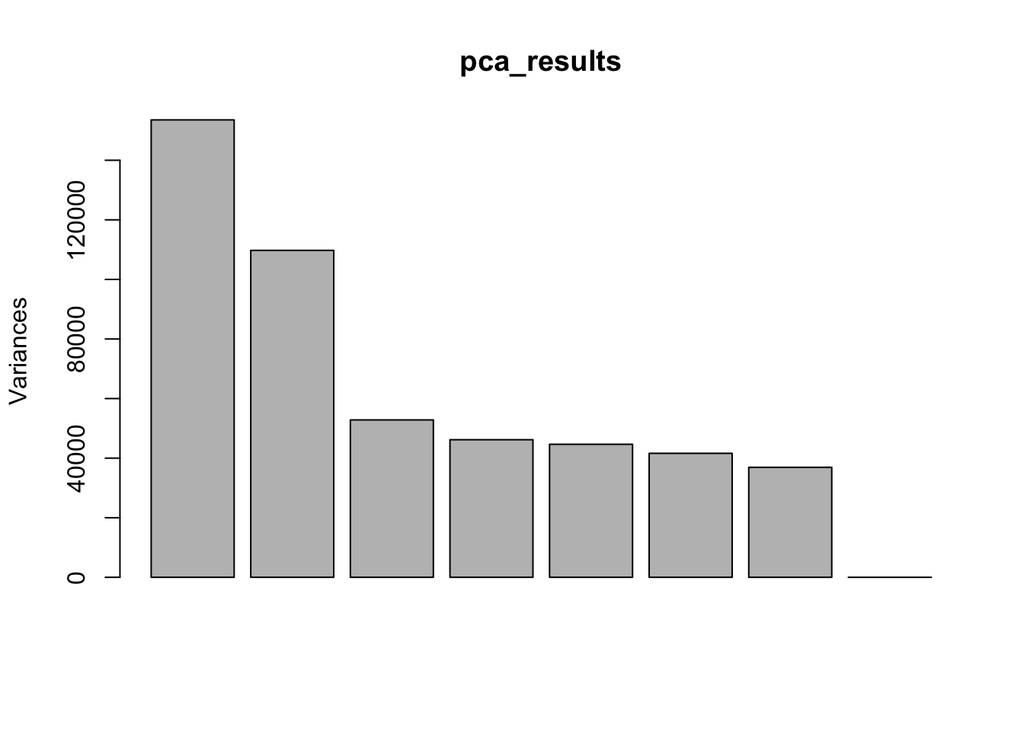

```r
plot(pca_results)
```

We ask the str() of pca_object

```r
str(pca_results)
```

```
## List of 5
##  $ sdev    : num [1:8] 392 331 230 215 211 ...
##  $ rotation: num [1:485512, 1:8] -0.000628 0.000745 0.000112 0.001532 0.000512 ...
##   ..- attr(*, "dimnames")=List of 2
##   .. ..$ : chr [1:485512] "cg13869341" "cg14008030" "cg12045430" "cg20826792" ...
##   .. ..$ : chr [1:8] "PC1" "PC2" "PC3" "PC4" ...
##  $ center  : Named num [1:485512] 0.759 0.645 0.161 0.262 0.121 ...
##   ..- attr(*, "names")= chr [1:485512] "cg13869341" "cg14008030" "cg12045430" "cg20826792" ...
##  $ scale   : Named num [1:485512] 0.038 0.0454 0.1077 0.0563 0.0791 ...
##   ..- attr(*, "names")= chr [1:485512] "cg13869341" "cg14008030" "cg12045430" "cg20826792" ...
##  $ x       : num [1:8, 1:8] -158.6 190.4 424.1 83.7 -837 ...
##   ..- attr(*, "dimnames")=List of 2
##   .. ..$ : chr [1:8] "9344737127_R01C02" "9344737127_R03C02" "9344737127_R06C01" "9344737127_R02C02" ...
##   .. ..$ : chr [1:8] "PC1" "PC2" "PC3" "PC4" ...
##  - attr(*, "class")= chr "prcomp"
```

The principal components of interest are stored in the element named “x” of the list.

```r
pca_results$x
```

```
##                          PC1        PC2           PC3         PC4         PC5
## 9344737127_R01C02 -158.58603 -499.02472 -275.41715532  122.618476   63.103916
## 9344737127_R03C02  190.36771   54.85588  -10.44934909 -422.344011  286.008070
## 9344737127_R06C01  424.12532  361.80718 -190.88012776  -38.629569 -340.971394
## 9344737127_R02C02   83.72623 -157.69358 -165.95380244  121.382496   25.566631
## 9376538140_R02C01 -837.02417  411.90073  -27.57991961    6.732864    1.214454
## 9376538140_R05C01 -140.28255 -378.89468  382.74022937 -124.204288 -259.654230
## 9376538140_R01C01  146.29094  -10.05157    0.09490818   21.863162   19.690139
## 9376538140_R04C01  291.38255  217.10075  287.44521666  312.580870  205.042413
##                            PC6         PC7           PC8
## 9344737127_R01C02  195.6548455 -184.495680  4.734989e-12
## 9344737127_R03C02   77.9751406   26.604105  1.644667e-12
## 9344737127_R06C01  127.9446991  -39.219304 -7.275352e-12
## 9344737127_R02C02 -148.9712326  406.012545  3.145954e-12
## 9376538140_R02C01    0.3277534    6.308337 -5.346196e-12
## 9376538140_R05C01   32.9674550   41.149318  3.497691e-12
## 9376538140_R01C01 -431.4333949 -234.806100  3.080572e-12
## 9376538140_R04C01  145.5347339  -21.553222  4.233926e-12
```

We can plot PC1 and PC2 and check if samples cluster according to some variable; the argument “cex” defines the size of the dots, the argument “pch” the dot type:

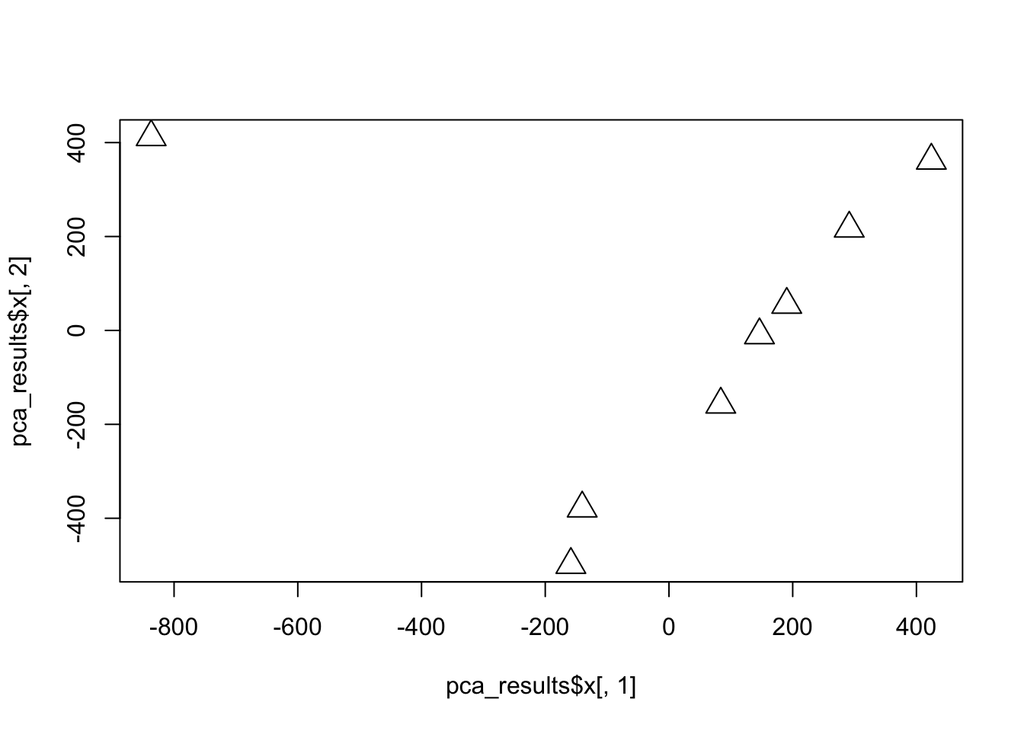

```r
plot(pca_results$x[,1], pca_results$x[,2],cex=2,pch=2)
```

We can label the dots using the text() function and setting the “labels” argument to the rownames of pca_results$x; the argument “pos” defines the position of the text:

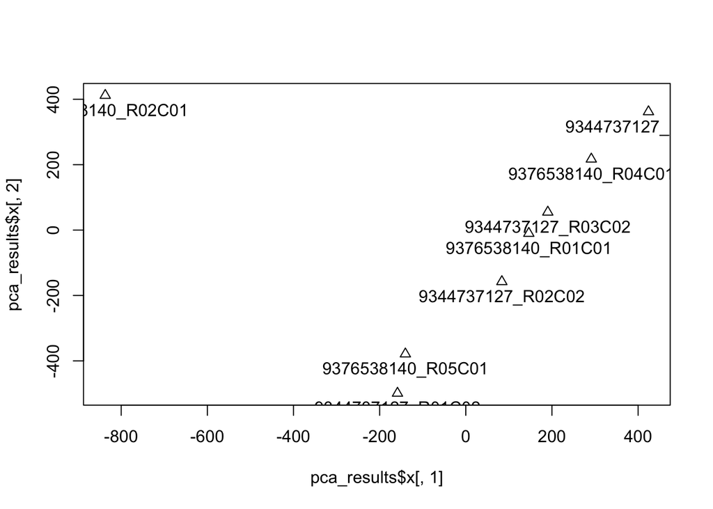

```r
?text
plot(pca_results$x[,1], pca_results$x[,2],cex=1,pch=2)
text(pca_results$x[,1], pca_results$x[,2],labels=rownames(pca_results$x),pos=1)
```

Sample 9376538140_R02C01 seems to be an outlier…

In this dataset we have few samples, so it is ok to plot their names. When you work with larger datasets, on the contrary, it is easier to colour the dots according to some column of the pheno file of interest, for example Group:

```r
pheno$Group
```

```
## [1] A A B B A A B B
## Levels: A B
```

We define a palette of colours; each colour will be assigned to each levels of the factor according to the order of levels. For example, in this case Group A will be in orange, Group B in purple. We will also adjust the margins and add a legend to the plot.

```r
levels(pheno$Group)
```

```
## [1] "A" "B"
```

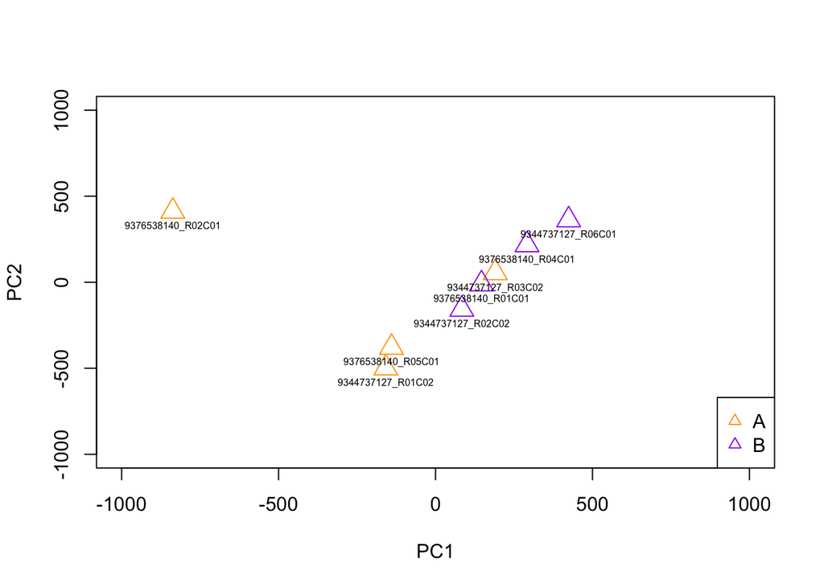

```r
palette(c("orange","purple"))
plot(pca_results$x[,1], pca_results$x[,2],cex=2,pch=2,col=pheno$Group,xlab="PC1",ylab="PC2",xlim=c(-1000,1000),ylim=c(-1000,1000))
text(pca_results$x[,1], pca_results$x[,2],labels=rownames(pca_results$x),cex=0.5,pos=1)
legend("bottomright",legend=levels(pheno$Group),col=c(1:nlevels(pheno$Group)),pch=2)
```

Another example coloring according to the sex of the subjects.

```r
levels(pheno$Gender)
```

```
## [1] "F" "M"
```

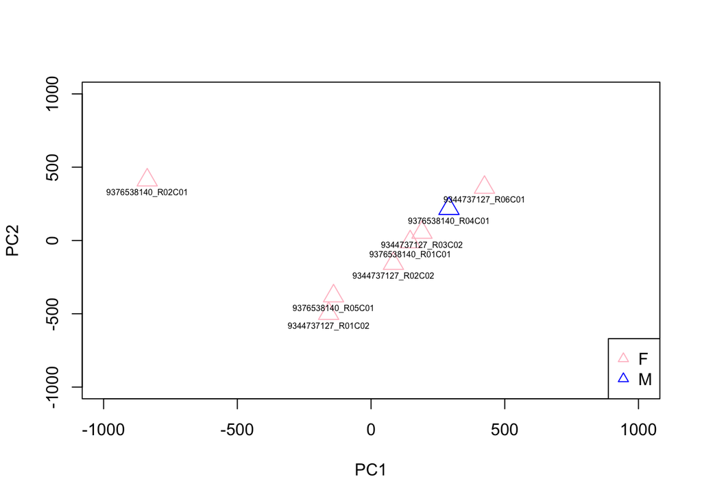

```r
palette(c("pink","blue"))
plot(pca_results$x[,1], pca_results$x[,2],cex=2,pch=2,col=pheno$Gender,xlab="PC1",ylab="PC2",xlim=c(-1000,1000),ylim=c(-1000,1000))
text(pca_results$x[,1], pca_results$x[,2],labels=rownames(pca_results$x),cex=0.5,pos=1)
legend("bottomright",legend=levels(pheno$Gender),col=c(1:nlevels(pheno$Group)),pch=2)
```

**CHUNK 2: Batch Effect Removal**. Omics experiments are sometimes affected by batch effects, that is unwanted variations in the data that arise due to external factors like experimental conditions or equipment, rather than biological differences.  
Let’s preview our data to check for batch effects:

```r
levels(pheno$Slide)
```

pheno$Slide has no levels because it is read as a numeric vector. Convert it into a factor for correct pca plot coloring.

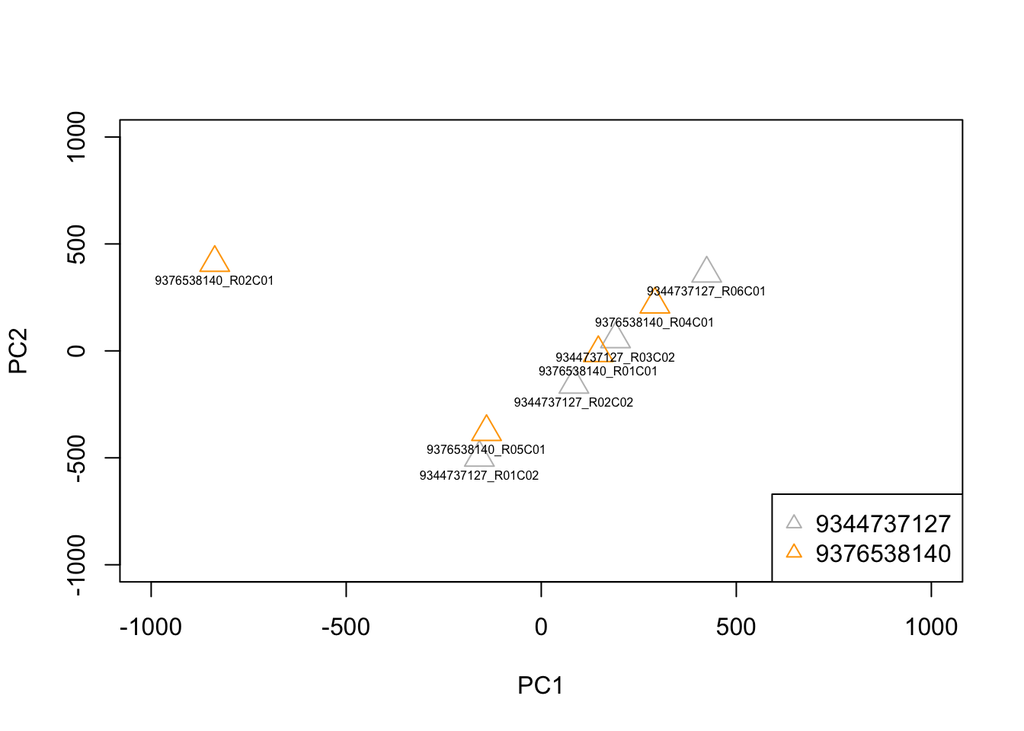

```r
pheno$Slide <- factor(pheno$Slide)
palette(c("grey","orange"))
plot(pca_results$x[,1], pca_results$x[,2],cex=2,pch=2,col=pheno$Slide,xlab="PC1",ylab="PC2",xlim=c(-1000,1000),ylim=c(-1000,1000))
text(pca_results$x[,1], pca_results$x[,2],labels=rownames(pca_results$x),cex=0.5,pos=1)
legend("bottomright",legend=levels(pheno$Slide),col=c(1:nlevels(pheno$Group)),pch=2)
```

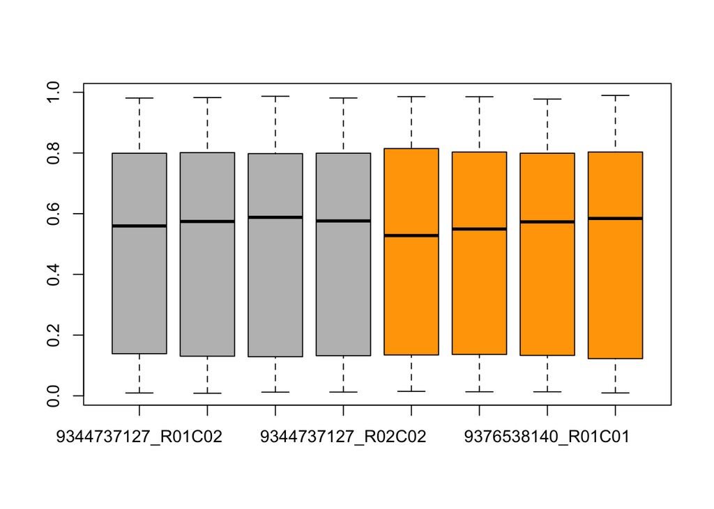

```r
boxplot(beta_preprocessQuantile, col=pheno$Slide)
```

We do not see a clear batch effect in our dataset, good!  
Although our data seems to be devoid of batch effects let’s check what happens if we apply batch effect correction.

Batch effect correction on DNA methylation data is performed using the **ComBat()** function, which is part of the sva package.  
ComBat() adjusts for known batches using an empirical Bayesian framework, helping to remove these batch effects and make the data more reliable for downstream analysis.  
Sva package sva can be downloaded and installed by running:

```
BiocManager::install("sva")
```

```r
library(sva)
mod.null <- model.matrix(~as.factor(Group), data = pheno)
batch <- as.factor(pheno$Slide)
combat_edata <- ComBat(dat = beta_preprocessQuantile, batch = batch, mod = mod.null)
```

```
## Found2batches
```

```
## Adjusting for1covariate(s) or covariate level(s)
```

```
## Standardizing Data across genes
```

```
## Fitting L/S model and finding priors
```

```
## Finding parametric adjustments
```

```
## Adjusting the Data
```

```r
str(combat_edata)
```

```
##  num [1:485512, 1:8] 0.7548 0.681 0.1618 0.18 0.0774 ...
##  - attr(*, "dimnames")=List of 2
##   ..$ : chr [1:485512] "cg13869341" "cg14008030" "cg12045430" "cg20826792" ...
##   ..$ : chr [1:8] "9344737127_R01C02" "9344737127_R03C02" "9344737127_R06C01" "9344737127_R02C02" ...
```

```r
Quantile_Combat_beta <- as.data.frame(combat_edata)
```

And now let’s see how ComBat has modified our data! We will calculate again PCA and plot PC1 and PC2 according to Group, Gender and Slide.

```r
Tbeta_ComBat <- t(Quantile_Combat_beta)
pca_result_ComBat <- prcomp(Tbeta_ComBat, scale = TRUE)

levels(pheno$Group)
```

```
## [1] "A" "B"
```

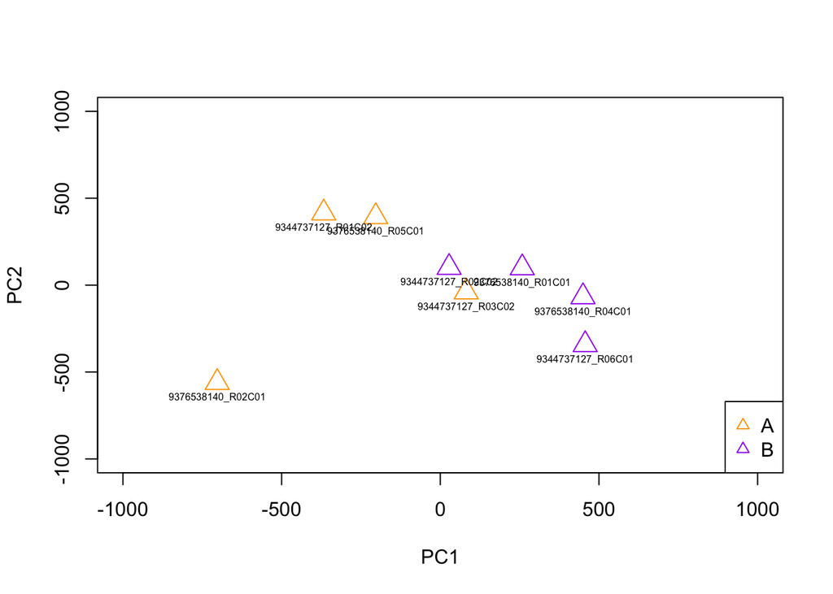

```r
palette(c("orange","purple"))
plot(pca_result_ComBat$x[,1], pca_result_ComBat$x[,2],cex=2,pch=2,col=pheno$Group,xlab="PC1",ylab="PC2",xlim=c(-1000,1000),ylim=c(-1000,1000))
text(pca_result_ComBat$x[,1], pca_result_ComBat$x[,2],labels=rownames(pca_result_ComBat$x),cex=0.5,pos=1)
legend("bottomright",legend=levels(pheno$Group),col=c(1:nlevels(pheno$Group)),pch=2)
```

```r
levels(pheno$Gender)
```

```
## [1] "F" "M"
```

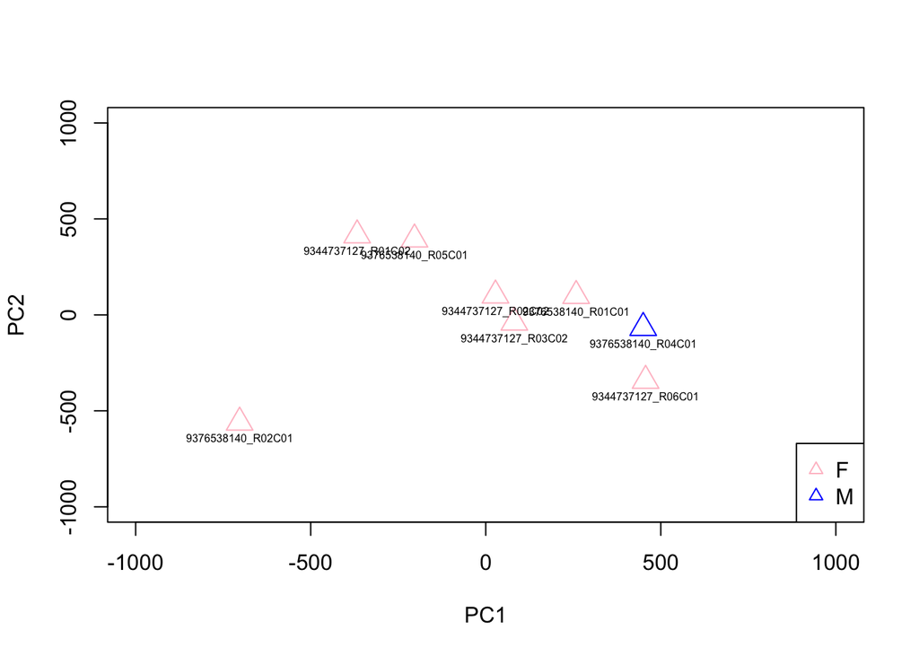

```r
palette(c("pink","blue"))
plot(pca_result_ComBat$x[,1], pca_result_ComBat$x[,2],cex=2,pch=2,col=pheno$Gender,xlab="PC1",ylab="PC2",xlim=c(-1000,1000),ylim=c(-1000,1000))
text(pca_result_ComBat$x[,1], pca_result_ComBat$x[,2],labels=rownames(pca_result_ComBat$x),cex=0.5,pos=1)
legend("bottomright",legend=levels(pheno$Gender),col=c(1:nlevels(pheno$Group)),pch=2)
```

```r
levels(pheno$Slide)
```

```
## [1] "9344737127" "9376538140"
```

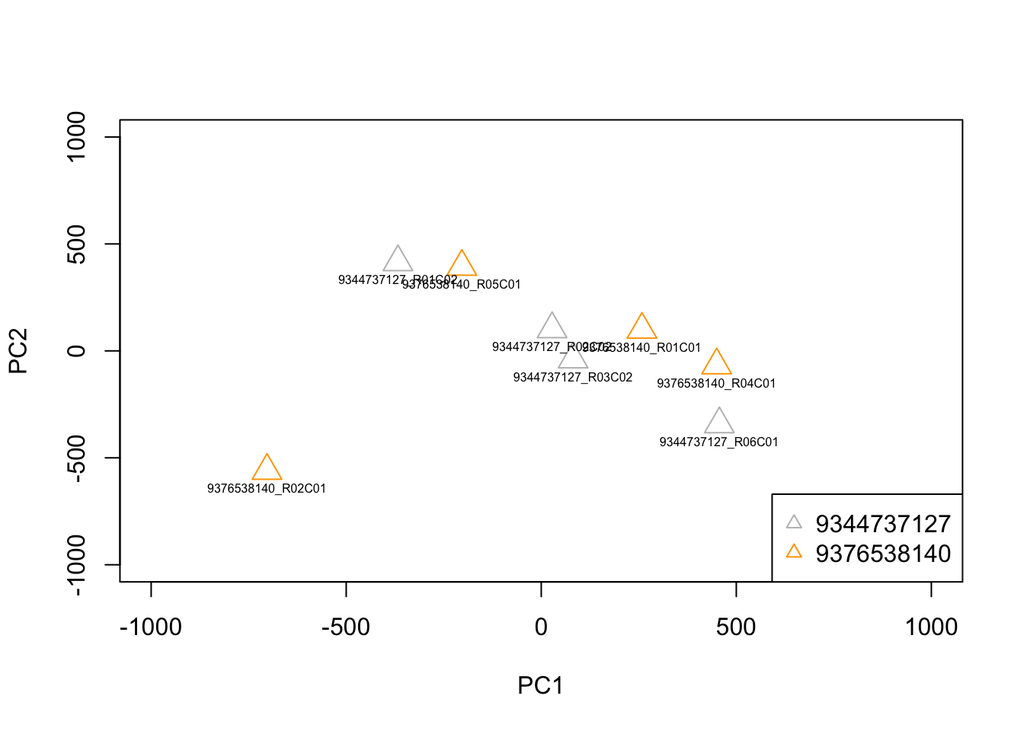

```r
palette(c("grey","orange"))
plot(pca_result_ComBat$x[,1], pca_result_ComBat$x[,2],cex=2,pch=2,col=pheno$Slide,xlab="PC1",ylab="PC2",xlim=c(-1000,1000),ylim=c(-1000,1000))
text(pca_result_ComBat$x[,1], pca_result_ComBat$x[,2],labels=rownames(pca_result_ComBat$x),cex=0.5,pos=1)
legend("bottomright",legend=levels(pheno$Slide),col=c(1:nlevels(pheno$Group)),pch=2)
```

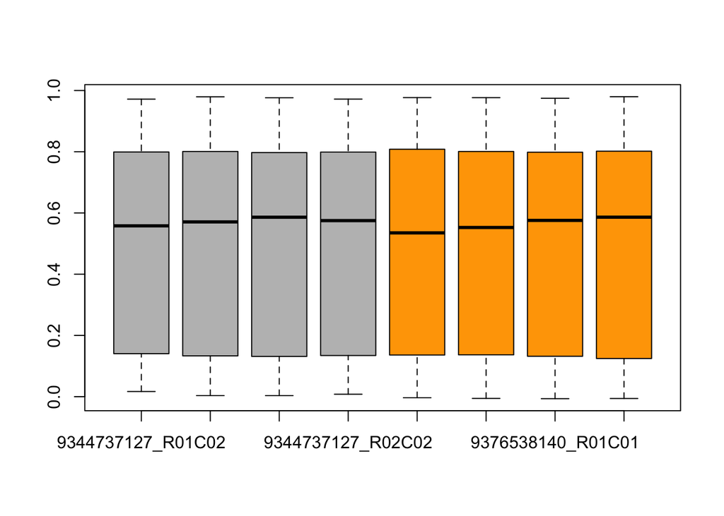

```r
boxplot(Quantile_Combat_beta,col=pheno$Slide)
```

Batch has a minimal effect on data variability. Batch effect correction did not result in large changes in beta value distribution nor in data variability.

**Exercise 1**: Load beta_CRC.RData and Samplesheet_CRC.txt. Plot beta value distribution (using boxplot) and Principal Components (using PCA plot) and check for batch effects.  
Do you notice a batch effect on data? Remove batch effect from data using ComBat() function. Check the dataset again using the plotting functions above. Are there any differences compared to uncorrected data?